# Practical Machine Learning Project

M Azahari Yaakub

The goal of your project is to predict the manner in which they did the exercise. This is the “classe” variable in the training set. You may use any of the other variables to predict with. You should create a report describing how you built your model, how you used cross validation, what you think the expected out of sample error is, and why you made the choices you did. You will also use your prediction model to predict 20 different test cases.

1. Your submission should consist of a link to a Github repo with your R markdown and compiled HTML file describing your analysis. Please constrain the text of the writeup to < 2000 words and the number of figures to be less than 5. It will make it easier for the graders if you submit a repo with a gh-pages branch so the HTML page can be viewed online (and you always want to make it easy on graders :-).
2. You should also apply your machine learning algorithm to the 20 test cases available in the test data above. Please submit your predictions in appropriate format to the programming assignment for automated grading. See the programming assignment for additional details.

The data for this project come from this http://groupware.les.inf.puc-rio.br/har. If you use the document you create for this class for any purpose please cite them as they have been very generous in allowing their data to be used for this kind of assignment.

```r
library(pROC)
library(caret)
library(kernlab)
library(ggplot2)
library(rpart)
library(rpart.plot)
library(RColorBrewer)
library(rattle)
library(randomForest)
library(gbm)
```

### Get the Training and Testing Data Sets

```r
if (!file.exists("pml-training.csv")) {
  file.url<-"https://d396qusza40orc.cloudfront.net/predmachlearn/pml-training.csv"
  download.file(file.url,destfile='pml-training.csv')
}

if (!file.exists("pml-testing.csv")) {
  file.url<-"https://d396qusza40orc.cloudfront.net/predmachlearn/pml-testing.csv"
  download.file(file.url,destfile='pml-testing.csv')
}
```

### Read Data Sets

```r
testing<-read.csv(file="pml-testing.csv",head=TRUE,sep=",",na.strings = c("NA", "", "#DIV/0!"))
training<-read.csv(file="pml-training.csv",head=TRUE,sep=",", na.strings = c("NA", "", "#DIV/0!"))
dim(training);dim(testing)
```

```
## [1] 19622   160
```

```
## [1]  20 160
```

```r
training$classe<-as.factor(training$classe)
```

### Clean Train and Test Data Sets

```r
NAindex <- apply(training,2,function(x) {sum(is.na(x))})
training <- training[,which(NAindex == 0)]
NAindex <- apply(testing,2,function(x) {sum(is.na(x))})
testing <- testing[,which(NAindex == 0)]

v <- which(lapply(training, class) %in% "numeric")

preObj <-preProcess(training[,v],method=c('knnImpute', 'center', 'scale'))
trainLess1 <- predict(preObj, training[,v])
trainLess1$classe <- training$classe

testLess1 <-predict(preObj,testing[,v])

nzv <- nearZeroVar(trainLess1,saveMetrics=TRUE)
trainLess1 <- trainLess1[,nzv$nzv==FALSE]

nzv <- nearZeroVar(testLess1,saveMetrics=TRUE)
testLess1 <- testLess1[,nzv$nzv==FALSE]
```

### Partition Data Sets

```r
inTrain <- createDataPartition(trainLess1$classe, p=0.6, list=FALSE)
myTraining <- trainLess1[inTrain, ]
myTesting <- trainLess1[-inTrain, ]
```

### Prediction Model - Decision Trees

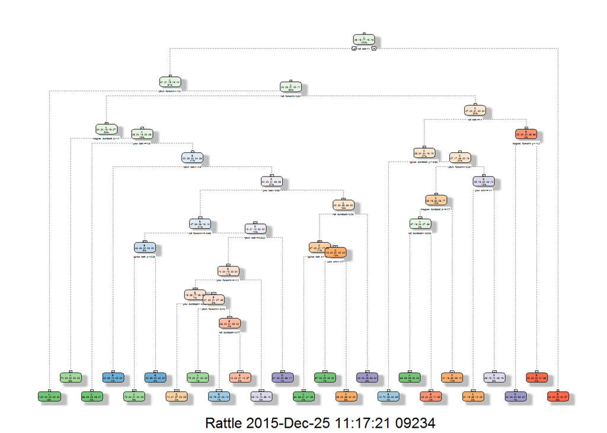

```r
set.seed(8888)
modFitA1 <- rpart(classe ~ ., data=myTraining, method="class")
fancyRpartPlot(modFitA1)
```

```r
predictionsA1 <- predict(modFitA1, myTesting, type = "class")
cmtree <- confusionMatrix(predictionsA1, myTesting$classe)
cmtree
```

```
## Confusion Matrix and Statistics
##
##           Reference
## Prediction    A    B    C    D    E
##          A 1996  296   16   63   31
##          B   30  746   52   17   52
##          C   80  251 1144  226  143
##          D   65  130  148  923  182
##          E   61   95    8   57 1034
##
## Overall Statistics
##
##                Accuracy : 0.7447
##                  95% CI : (0.7349, 0.7543)
##     No Information Rate : 0.2845
##     P-Value [Acc > NIR] : < 2.2e-16
##
##                   Kappa : 0.6769
##  Mcnemar's Test P-Value : < 2.2e-16
##
## Statistics by Class:
##
##                      Class: A Class: B Class: C Class: D Class: E
## Sensitivity            0.8943  0.49144   0.8363   0.7177   0.7171
## Specificity            0.9277  0.97614   0.8919   0.9200   0.9655
## Pos Pred Value         0.8310  0.83166   0.6204   0.6374   0.8239
## Neg Pred Value         0.9566  0.88890   0.9627   0.9433   0.9381
## Prevalence             0.2845  0.19347   0.1744   0.1639   0.1838
## Detection Rate         0.2544  0.09508   0.1458   0.1176   0.1318
## Detection Prevalence   0.3061  0.11433   0.2350   0.1846   0.1600
## Balanced Accuracy      0.9110  0.73379   0.8641   0.8188   0.8413
```

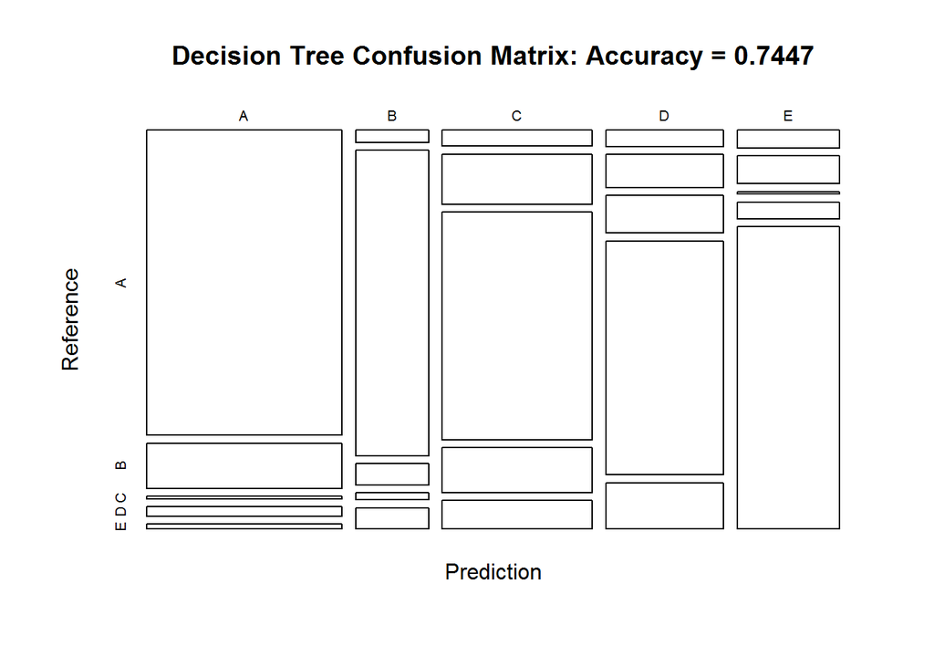

```r
plot(cmtree$table, col = cmtree$byClass, main = paste("Decision Tree Confusion Matrix: Accuracy =", round(cmtree$overall['Accuracy'], 4)))
```

### Prediction Model - Random Forests

```r
set.seed(8888)
modFitB1 <- randomForest(classe ~ ., data=myTraining)
predictionB1 <- predict(modFitB1, myTesting, type = "class")
cmrf <- confusionMatrix(predictionB1, myTesting$classe)
cmrf
```

```
## Confusion Matrix and Statistics
##
##           Reference
## Prediction    A    B    C    D    E
##          A 2231   16    0    0    0
##          B    1 1489    4    0    0
##          C    0   13 1356   12    5
##          D    0    0    8 1272    6
##          E    0    0    0    2 1431
##
## Overall Statistics
##
##                Accuracy : 0.9915
##                  95% CI : (0.9892, 0.9934)
##     No Information Rate : 0.2845
##     P-Value [Acc > NIR] : < 2.2e-16
##
##                   Kappa : 0.9892
##  Mcnemar's Test P-Value : NA
##
## Statistics by Class:
##
##                      Class: A Class: B Class: C Class: D Class: E
## Sensitivity            0.9996   0.9809   0.9912   0.9891   0.9924
## Specificity            0.9971   0.9992   0.9954   0.9979   0.9997
## Pos Pred Value         0.9929   0.9967   0.9784   0.9891   0.9986
## Neg Pred Value         0.9998   0.9954   0.9981   0.9979   0.9983
## Prevalence             0.2845   0.1935   0.1744   0.1639   0.1838
## Detection Rate         0.2843   0.1898   0.1728   0.1621   0.1824
## Detection Prevalence   0.2864   0.1904   0.1767   0.1639   0.1826
## Balanced Accuracy      0.9984   0.9901   0.9933   0.9935   0.9960
```

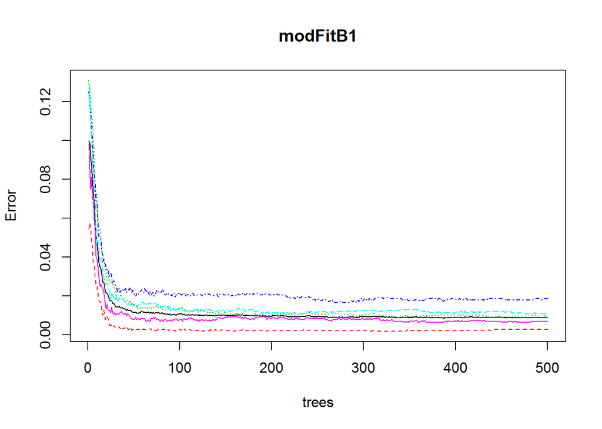

```r
plot(modFitB1)
```

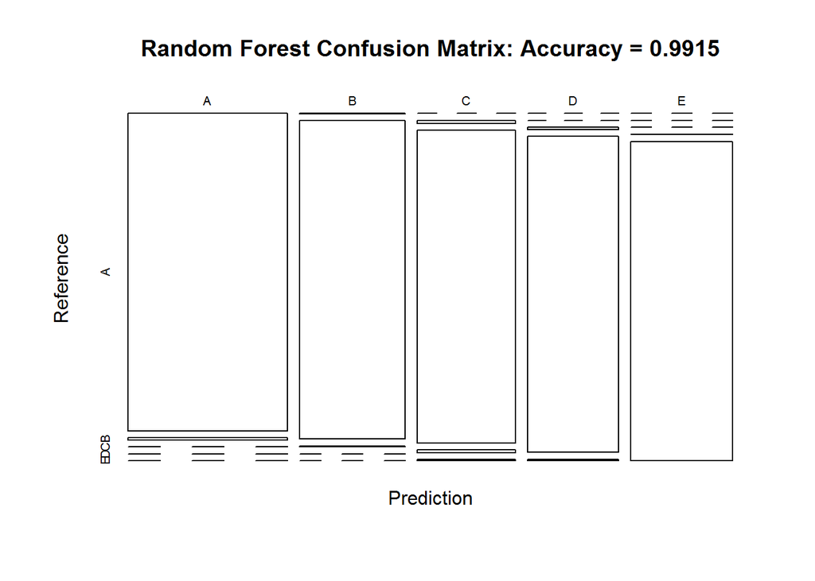

```r
plot(cmrf$table, col = cmtree$byClass, main = paste("Random Forest Confusion Matrix: Accuracy =", round(cmrf$overall['Accuracy'], 4)))
```

### Prediction Model - GBM

```r
set.seed(8888)
fitControl <- trainControl(method = "repeatedcv", number = 5, repeats = 1)

gbmFit1 <- train(classe ~ ., data=myTraining, method = "gbm", trControl = fitControl, verbose = FALSE)
gbmFinMod1 <- gbmFit1$finalModel

gbmPredTest <- predict(gbmFit1, newdata=myTesting)
gbmAccuracyTest <- confusionMatrix(gbmPredTest, myTesting$classe)
gbmAccuracyTest
```

```
## Confusion Matrix and Statistics
##
##           Reference
## Prediction    A    B    C    D    E
##          A 2180   68    3    4    7
##          B   30 1387   58   15   23
##          C    9   56 1285   36   28
##          D    7    3   20 1219   40
##          E    6    4    2   12 1344
##
## Overall Statistics
##
##                Accuracy : 0.9451
##                  95% CI : (0.9398, 0.95)
##     No Information Rate : 0.2845
##     P-Value [Acc > NIR] : < 2.2e-16
##
##                   Kappa : 0.9305
##  Mcnemar's Test P-Value : 1.843e-13
##
## Statistics by Class:
##
##                      Class: A Class: B Class: C Class: D Class: E
## Sensitivity            0.9767   0.9137   0.9393   0.9479   0.9320
## Specificity            0.9854   0.9801   0.9801   0.9893   0.9963
## Pos Pred Value         0.9637   0.9167   0.9088   0.9457   0.9825
## Neg Pred Value         0.9907   0.9793   0.9871   0.9898   0.9849
## Prevalence             0.2845   0.1935   0.1744   0.1639   0.1838
## Detection Rate         0.2778   0.1768   0.1638   0.1554   0.1713
## Detection Prevalence   0.2883   0.1928   0.1802   0.1643   0.1744
## Balanced Accuracy      0.9810   0.9469   0.9597   0.9686   0.9641
```

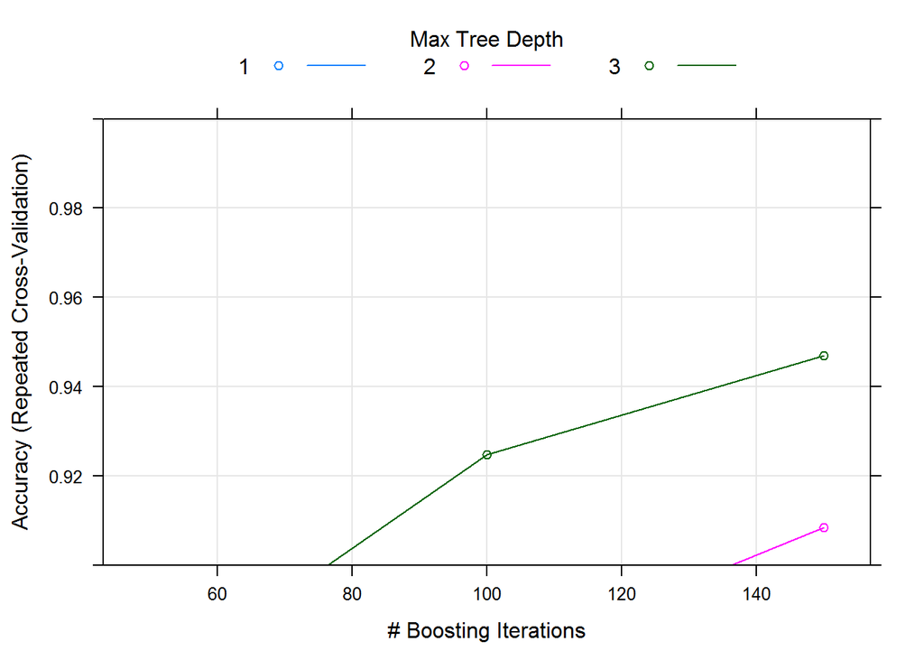

```r
plot(gbmFit1, ylim=c(0.9, 1))
```

### Prediction using Testing data set

From previous prediction model built, Random Forest achieved better accuracy than others. So, we use this model for our testing data set.

```r
predictionB2 <- predict(modFitB1, testLess1, type = "class")
predictionB2
```

```
##  1  2  3  4  5  6  7  8  9 10 11 12 13 14 15 16 17 18 19 20
##  B  A  B  A  A  E  D  B  A  A  B  C  B  A  E  E  A  B  B  B
## Levels: A B C D E
```

### Generate the output files

```r
pml_write_files <- function (x) {
  n <- length(x)
  for (i in 1:20) {
    filename <- paste0("problem_id_",i,".txt")
    write.table(x[i],file=filename,quote=FALSE,row.names=FALSE,col.names=FALSE)
  }
}

pml_write_files(predictionB2)
```